# Coarse SNNM: DIH Prosecutions

Kelly Kung

3/30/2022

# 1 Set Up

## 1.1 R Code

```r
#packages we need for this code file
library(ggplot2)
library(mgcv)
library(lubridate)
library(zoo)
library(tidyverse)
library(dplyr)
library(aod)
library("plot3D")
```

```r
#define functions we will need for analysis
#expit function
expit<-function(x){
  return(exp(x)/(1 + exp(x)))
}

#logit function
logit<-function(x){
  return(log(x/(1 - x)))
}
```

## 1.2 Data

```r
#read in data
main_analysis_data<-read.csv("./Data/full_data_set_11_29_21_unintentional.csv")

################################## set up data set ################################
#add the intervention dates and time period data
main_analysis_data$Intervention_First_Date<-as.Date(main_analysis_data$Intervention_First_Date)
main_analysis_data$Time_Period_Start<-as.Date(main_analysis_data$Time_Period_Start)
names(main_analysis_data)[which(colnames(main_analysis_data) == "sum_deaths")] <- "imputed_deaths"
main_analysis_data$dih_exposure <- as.numeric(main_analysis_data$Intervention_Redefined > 0)
#compute the risk of overdose death
main_analysis_data$prop_dead <- main_analysis_data$imputed_deaths/main_analysis_data$population
```

# 2 Model for Treatment Effect

## 2.1 Create Dataset

```r
#create sum of policies already enacted for treatment initiation
#create a new dataset treat_data for which we can make changes to
treat_data <- main_analysis_data
#we first create lag variables for the policies so that we know that by time t, whether the policy has been enacted
#note that we don't count what happened at time t
treat_data <- treat_data %>%
  #make sure that the data is ordered according to first state and then time period
  arrange(State, Time_Period_ID) %>%
  #group by state so that when we lag, we only lag within the state
  group_by(State) %>%
  mutate(lag_tx = lag(dih_exposure),
         lag_naloxone_pharm_yes = lag(Naloxone_Pharmacy_Yes_Redefined),
         lag_naloxone_pharm_no = lag(Naloxone_Pharmacy_No_Redefined),
         lag_medical_marijuana = lag(Medical_Marijuana_Redefined),
         lag_rec_marijuana = lag(Recreational_Marijuana_Redefined),
         lag_gsl = lag(GSL_Redefined),
         lag_pdmp = lag(PDMP_Redefined),
         lag_medicaid = lag(Medicaid_Expansion_Redefined),
         lag_intervention = lag(Intervention_Redefined))

#since we lag the variables, the entry at time 1 will be NA. Since we have start dates of the different policies, I checked to
#see which policies were enacted before Jan 1, 2000.
#if the policies were enacted before Jan 1, 2000, I impute a 1 for the first time period, otherwise a 0
treat_data$lag_tx[treat_data$Time_Period_ID == 1] <-
  treat_data$lag_naloxone_pharm_yes[treat_data$Time_Period_ID == 1] <-
  treat_data$lag_naloxone_pharm_no[treat_data$Time_Period_ID == 1] <-
  treat_data$lag_rec_marijuana[treat_data$Time_Period_ID == 1] <-
  treat_data$lag_gsl[treat_data$Time_Period_ID == 1] <-
  treat_data$lag_medicaid[treat_data$Time_Period_ID == 1] <-
  treat_data$lag_intervention[treat_data$Time_Period_ID == 1]<-0

treat_data$lag_medical_marijuana[treat_data$Time_Period_ID == 1 &
                                   treat_data$State %in%
                                   c("Alaska", "California", "Maine", "Oregon", "Washington")] <- 1
treat_data$lag_medical_marijuana[treat_data$Time_Period_ID == 1  &
                                   !(treat_data$State %in%
                                       c("Alaska", "California", "Maine", "Oregon", "Washington"))] <- 0

treat_data$lag_pdmp[treat_data$Time_Period_ID == 1  &
                                   treat_data$State %in%
                      c("California", "Hawaii", "Idaho", "Illinois", "Indiana",
                        "Kentucky", "Massachusetts", "Michigan", "Nevada",
                        "New York", "Oklahoma", "Pennsylvania", "Rhode Island",
                        "Texas", "Utah", "West Virginia")] <- 1
treat_data$lag_pdmp[treat_data$Time_Period_ID == 1  &
                                   !(treat_data$State %in%
                                       c("California", "Hawaii", "Idaho", "Illinois", "Indiana",
                                         "Kentucky", "Massachusetts", "Michigan", "Nevada",
                                         "New York", "Oklahoma", "Pennsylvania", "Rhode Island",
                                         "Texas", "Utah", "West Virginia"))] <- 0

#create a new variable that indicates the number of policies that have been enacted by time t
treat_data$sum_policies <- treat_data$lag_naloxone_pharm_yes +
  treat_data$lag_naloxone_pharm_no +
  treat_data$lag_medical_marijuana +
  treat_data$lag_rec_marijuana +
  treat_data$lag_gsl +
  treat_data$lag_pdmp +
  treat_data$lag_medicaid

#impute Hawaii's treatment date as something far off in the future
treat_data$Intervention_First_Date[treat_data$State == "Hawaii"] <- as.Date("9999-01-01")
```

# 3 One Parameter Model: Binary Treatment Variable

## 3.1 Mimicking Potential Outcomes

To compute the mimicked potential outcome: $H_{s,k}(t)$ for $k \in \{7-2019, \dotsc, 7-2000 \}$ and $t < k$, we first extract $Y_{s,k}$. We then compute $\gamma_t^k = exp(\psi*(a_{s,t} - a_{s,t-1}))$. Let $t_s^*$ be the treatment time interval for state $s$. We focus on data points for which $t \leq t_s^*$ and $t<k$. This is because for the treatment initiation model, we include data points for which $t \leq t_s^*$ and we want $t<k$. We let $a_{s,t}$ be a binary variable. For these data points we are intersted in, we create the variable `hkt` which is equal to $\frac{Y_{s,k}}{exp(\psi)}$ when $k > t_s^*$ (i.e. $Y_{s,k}$ is a treated outcome) and equal to $Y_{s,k}$ when $k \leq t_s^*$ (i.e. $Y_{s,k}$ is an untreated outcome). Lastly, we combine all these datapoints together for each $k$ into a dataset to be returned to use in the treatment initiation model.

```r
compute_mimick_potential_outcome <- function(dataFrame, gamma_k_t_when_treated){
  #new_df is the dataset we will return, with the new rows appended
  #we initialize it first as the input dataset df
  new_data_frame <- data.frame()

  #here, k is the time in which we observe the outcome and t is the time of the treatments
  #so we have k > t
  for(k in max(unique(dataFrame$Time_Period_ID)):2){
    #we first pull out the risk of OD at time k, so Y_k
    outcome_k_data <- dataFrame %>%
      arrange(State) %>%
      filter(Time_Period_ID == k) %>%
      dplyr::select(State, prop_dead, Intervention_First_Date, Time_Period_Start)

    #compute H_k(t) given gamma_k_t_when_treated:
    #here, let t^* = treatment time
    #if k <= t^*, then H_k(t) = Y_k since we havent treated yet, so doesn't affect
    #if t^* < t < k, then H_k(t) = Y_k since a_{t} - a_{t-1} = 0
    #if t <= t^* < k, then H_k(t) = Y_k/gamma_k_t_when_treated
    outcome_k_data$hkt <- ifelse(outcome_k_data$Time_Period_Start > outcome_k_data$Intervention_First_Date,
                                 outcome_k_data$prop_dead/gamma_k_t_when_treated, outcome_k_data$prop_dead)

    #filter the data for which A_{s,t} = 0 and the time interval that contains the treatment time since we only need these data
    #to predict treatment initiation for the model
    #we also filter so that the t < k
    untreated_and_first_tx_date_data <- dataFrame %>%
      arrange(State, Time_Period_ID) %>%
      #filter for t <= t^* because we use these time periods to predict treatment initiation
      filter(Time_Period_Start <= Intervention_First_Date,
             #filter for t < k
             Time_Period_ID < k)

    #merge the filtered dataset with the outcome_k_data which contains the computed H_k(t)
    untreated_and_first_tx_date_data <- merge(untreated_and_first_tx_date_data, outcome_k_data[,c("State", "hkt")], by = "State")

    #compute values that may be useful
    #compute k - t
    untreated_and_first_tx_date_data$k_minus_t <- k - untreated_and_first_tx_date_data$Time_Period_ID
    #compute indicator of whether Y_{s,k} is treated outcome
    untreated_and_first_tx_date_data$treated_outcome_indicator <- unique(outcome_k_data$Time_Period_Start) >
      untreated_and_first_tx_date_data$Intervention_First_Date

    #we then append the rows to the new_data_frame
    new_data_frame <- rbind(new_data_frame, untreated_and_first_tx_date_data)
  }
  new_data_frame
}
```

## 3.2 Finding $\psi$: $\gamma_t^k = exp(\psi (a_t - a_{t-1}))$

Here, we assume that the treatment effects model is given by the one parameter model:
$$\gamma_t^k = exp(\psi*(a_t - a_{t-1})),$$
where $a_t$ and $a_{t-1}$ are binary variables (for now) indicating whether there have ever been any DIH prosecution media alerts by time $t$ and $t-1$. Further, we have $k > t_s^*$.

We fit a treatment initiation model for the response `dih_exposure` which is a binary variable indicating whether the state was exposed to DIH prosecution in the media, where we use the following as predictors:

- `sum_policies` is the number of other policy measures that have been enacted from time 1 until time $t-1$
- `hkt` is the computed $H_k(t)$
- `Time_Period_ID` is the linear time effect.

Recall that the `model_data` only contains the datapoints for which $t \leq t^*$. For each value $\psi$, we extract the coefficient of `hkt` from the treatment initiation model, and we find the $\psi$ that leads to a coefficient of zero. We also store a vector of `conf_int` which stores the values of $\psi$ if the Wald test for the coefficient of `hkt` is not statistically significant at the $alpha = 0.05$ level.

```r
#create a vector of 100 psi
# psi_grid_params <- seq(-0.1012847, -0.1012846, length.out = 100)
psi_grid_params <- seq(-.2, .1, by = 0.001)

#initialize the vector of coefficients for H(t) in treatment initiation model
coef_hkt <- rep(NA, length(psi_grid_params))
conf_int <- c()
for(grid_point in 1:length(psi_grid_params)){
  #statement to print the status of the for loop
  # if(grid_point%%10 == 0){print(grid_point)}
  #compute gamma_k_t given the psi_grid_params[grid_point]. Since here, the treatment is binary, we only need the value for
  #exp(psi_grid_params[grid_point])
  gamma_k_t_when_treated <- exp(psi_grid_params[grid_point])

  #compute H(t) given the dataset and gamma_k_t_when_treated
  model_data <- compute_mimick_potential_outcome(treat_data, gamma_k_t_when_treated)

  #fit model for treatment initiation
  treat_model <- glm(dih_exposure~
                       sum_policies +
                       hkt +
                       Time_Period_ID,
                     data = model_data, family = "binomial")

  #store the coefficient for H_k(t)
  coef_hkt[grid_point] <- coef(treat_model)["hkt"]

  #conduct the Wald Test for the third coefficient, which is H_k(t) here since the first coefficient is the intercept
  store_wald_test <- wald.test(vcov(treat_model), coef(treat_model), 3)
  #we then store the p-value and store the psi values if the p-value > 0.05
  pval <- store_wald_test$result$chi2["P"]
  if(pval > 0.05){
    conf_int <- rbind(conf_int, psi_grid_params[grid_point])
  }
}

coef_hkt[179:180]
```

```
## [1]  1.463176 -9.335244
```

```r
psi_grid_params[179:180]
```

```
## [1] -0.022 -0.021
```

```r
as.vector(conf_int)
```

```
##   [1] -0.140 -0.139 -0.138 -0.137 -0.136 -0.135 -0.134 -0.133 -0.132 -0.131
##  [11] -0.130 -0.129 -0.128 -0.127 -0.126 -0.125 -0.124 -0.123 -0.122 -0.121
##  [21] -0.120 -0.119 -0.118 -0.117 -0.116 -0.115 -0.114 -0.113 -0.112 -0.111
##  [31] -0.110 -0.109 -0.108 -0.107 -0.106 -0.105 -0.104 -0.103 -0.102 -0.101
##  [41] -0.100 -0.099 -0.098 -0.097 -0.096 -0.095 -0.094 -0.093 -0.092 -0.091
##  [51] -0.090 -0.089 -0.088 -0.087 -0.086 -0.085 -0.084 -0.083 -0.082 -0.081
##  [61] -0.080 -0.079 -0.078 -0.077 -0.076 -0.075 -0.074 -0.073 -0.072 -0.071
##  [71] -0.070 -0.069 -0.068 -0.067 -0.066 -0.065 -0.064 -0.063 -0.062 -0.061
##  [81] -0.060 -0.059 -0.058 -0.057 -0.056 -0.055 -0.054 -0.053 -0.052 -0.051
##  [91] -0.050 -0.049 -0.048 -0.047 -0.046 -0.045 -0.044 -0.043 -0.042 -0.041
## [101] -0.040 -0.039 -0.038 -0.037 -0.036 -0.035 -0.034 -0.033 -0.032 -0.031
## [111] -0.030 -0.029 -0.028 -0.027 -0.026 -0.025 -0.024 -0.023 -0.022 -0.021
## [121] -0.020 -0.019 -0.018 -0.017 -0.016 -0.015 -0.014 -0.013 -0.012 -0.011
## [131] -0.010 -0.009 -0.008 -0.007 -0.006 -0.005 -0.004 -0.003 -0.002 -0.001
## [141]  0.000  0.001  0.002  0.003  0.004  0.005  0.006  0.007  0.008  0.009
## [151]  0.010  0.011  0.012  0.013  0.014  0.015  0.016  0.017  0.018  0.019
## [161]  0.020  0.021  0.022  0.023  0.024  0.025  0.026  0.027  0.028  0.029
## [171]  0.030  0.031  0.032  0.033  0.034  0.035  0.036  0.037  0.038  0.039
## [181]  0.040  0.041  0.042  0.043  0.044  0.045  0.046  0.047  0.048  0.049
## [191]  0.050  0.051  0.052  0.053  0.054  0.055  0.056  0.057  0.058  0.059
## [201]  0.060  0.061  0.062  0.063  0.064  0.065  0.066  0.067  0.068  0.069
## [211]  0.070  0.071  0.072  0.073  0.074  0.075  0.076  0.077  0.078  0.079
## [221]  0.080  0.081  0.082  0.083
```

```r
#-0.022
#(-0.140, 0.083)
```

The $\psi$ that produced an $\alpha(\psi)$, where $\alpha(\psi)$ is the coefficient of $H_k(t)$ in the treatment initiation model, that is closest to 0 is -0.022. The 95% Confidence Interval is (-0.140, 0.083).

## 3.3 Checking Grid-Search

Since we can compute the $\psi$ in a one-parameter model from the unbiased estimating equation, we do so to check the grid-search value. We showed that
$$E\left(\sum_s \sum_{k=1}^{T + 1} \sum_{t = k-1}^{T} \vec{q}{_t}^{k}(\bar{X}_{s,t}, \bar{A}_{s,t-1}) H_{s,k}(t) \mathbb{I}\{\bar{A}_{s,t-1} = \bar{0}\}({g(A}_{s,t}) - \lambda_{s,t})\right) = 0.$$
We let $\vec{q}{_t}^{k}(\bar{X}_{s,t}, \bar{A}_{s,t-1}) = 1$ and $H_{s,k}(t) = \frac{Y_{s,k}}{exp(\psi)} \mathbb{I}\{k > t_s^*\} + Y_{s,k} \mathbb{I}\{k \leq t_s^*\}$ where $t_s^*$ is the treatment time for state $s$. Furthermore, we let $g(A_{s,t}) = \mathbb{I}\{A_{s,t} > 0\}$ and $\lambda_{s,t} = p_{s,t}$, the probability of treatment. Then, we have the following:
$$\begin{align*}
0 &= \sum_s \sum_{k=1}^{T + 1} \sum_{t = 0}^{k-1} \left(\frac{Y_{s,k}}{exp(\psi)} \mathbb{I}\{k > t_s^*\} + Y_{s,k} \mathbb{I}\{k \leq t_s^*\}\right) \mathbb{I}\{\bar{A}_{s,t-1} = \bar{0}\}(\mathbb{I}\{A_{s,t} > 0\} - p_{s,t}) \\
&= \sum_s \sum_{k=1}^{T + 1} \sum_{t = 0}^{k-1} Y_{s,k}exp(-\psi) \mathbb{I}\{k > t_s^*\} \mathbb{I}\{\bar{A}_{s,t-1} = \bar{0}\}(\mathbb{I}\{A_{s,t} > 0\} - p_{s,t}) \\
&+ \sum_s \sum_{k=1}^{T + 1} \sum_{t = 0}^{k-1} Y_{s,k} \mathbb{I}\{k \leq t_s^*\} \mathbb{I}\{\bar{A}_{s,t-1} = \bar{0}\}(\mathbb{I}\{A_{s,t} > 0\} - p_{s,t}) \\
&\Rightarrow exp(-\psi) \sum_s \sum_{k=1}^{T + 1} \sum_{t = 0}^{k-1} Y_{s,k} \mathbb{I}\{k > t_s^*\} \mathbb{I}\{\bar{A}_{s,t-1} = \bar{0}\}(\mathbb{I}\{A_{s,t} > 0\} - p_{s,t}) = -\sum_s \sum_{k=1}^{T + 1} \sum_{t = 0}^{k-1} Y_{s,k} \mathbb{I}\{k \leq t_s^*\} \mathbb{I}\{\bar{A}_{s,t-1} = \bar{0}\}(\mathbb{I}\{A_{s,t} > 0\} - p_{s,t}) \\
&\Rightarrow exp(-\psi) = -\frac{\sum_s \sum_{k=1}^{T + 1} \sum_{t = 0}^{k-1} Y_{s,k} \mathbb{I}\{k \leq t_s^*\} \mathbb{I}\{\bar{A}_{s,t-1} = \bar{0}\}(\mathbb{I}\{A_{s,t} > 0\} - p_{s,t})}{\sum_s \sum_{k=1}^{T + 1} \sum_{t = 0}^{k-1} Y_{s,k} \mathbb{I}\{k > t_s^*\} \mathbb{I}\{\bar{A}_{s,t-1} = \bar{0}\}(\mathbb{I}\{A_{s,t} > 0\} - p_{s,t})} \\
&\Rightarrow \psi = - log\left(-\frac{\sum_s \sum_{k=1}^{T + 1} \sum_{t = 0}^{k-1} Y_{s,k} \mathbb{I}\{k \leq t_s^*\} \mathbb{I}\{\bar{A}_{s,t-1} = \bar{0}\}(\mathbb{I}\{A_{s,t} > 0\} - p_{s,t})}{\sum_s \sum_{k=1}^{T + 1} \sum_{t = 0}^{k-1} Y_{s,k} \mathbb{I}\{k > t_s^*\} \mathbb{I}\{\bar{A}_{s,t-1} = \bar{0}\}(\mathbb{I}\{A_{s,t} > 0\} - p_{s,t})}\right),
\end{align*}$$

where we model $p_{s,t}$ using the `sum_policies` and `Time_Period_ID` for data points in which $\bar{A}_{s,t-1} = \bar{0}$. However, if the fraction is positive, then we arrive at an issue since we cannot take the log of a negative.

```r
#filter the data to fit the treatment initiation model
treatment_initiation_data <- treat_data %>%
  # filter data so that t < t_s^* + 1
  filter(Intervention_Redefined < 1)

#fit the treatment initiation model
treatment_initiation_model <- glm(dih_exposure~
                                    sum_policies +
                                    Time_Period_ID,
                                  data = treatment_initiation_data,
                                  family = "binomial")

#compute the p_{s,t} and add it into the treatment_initiation_data
prob_tx <- fitted(treatment_initiation_model)
treatment_initiation_data$prob_tx <- prob_tx

#compute Y_{s,k} where periods k = 1, ..., T+1 for t = k-1, ..., T
#to do this, we can use the compute_mimick_potential_outcome() function with gamma_k_t_when_treated as 1
#we also compute an indicator of whether k > t_s^* to indicate whether it is a treated outcome or untreated outcome
data_w_Ysk <- compute_mimick_potential_outcome(treat_data, 1)

#merge the data with Y_{s,k} and the data with the probability of treatment
compute_psi_data <- merge(data_w_Ysk, treatment_initiation_data[,c("Time_Period_ID", "State", "prob_tx")],
                          by = c("Time_Period_ID", "State"))

#untreated outcome data to be used for numerator
untreated_outcome_data <- compute_psi_data[compute_psi_data$treated_outcome_indicator == FALSE,]
numerator <- sum(untreated_outcome_data$hkt*(untreated_outcome_data$dih_exposure - untreated_outcome_data$prob_tx))

#treated outcome data to be used for denominator
treated_outcome_data <- compute_psi_data[compute_psi_data$treated_outcome_indicator == TRUE,]
denominator <- sum(compute_psi_data$hkt*(compute_psi_data$dih_exposure - compute_psi_data$prob_tx))

-log(-numerator/denominator)
```

```
## [1] NaN
```

# 4 Two Parameter Model: Binary Treatment

## 4.1 Mimicking Potential Outcomes

To compute the mimicked potential outcome: $H_{s,k}(t)$ for $k \in \{7-2019, \dotsc, 7-2000 \}$ and $t < k$, we first extract $Y_{s,k}$. We then compute $\gamma_t^k = exp(\psi_1*(a_t - a_{t-1}) + \psi_2*(a_t - a_{t-1})*(k-t_s^*))$. Let $t_s^*$ be the treatment time interval for state $s$. We focus on data points for which $t \leq t_s^*$ and $t<k$. This is because for the treatment initiation model, we include data points for which $t \leq t_s^*$ and we want $t<k$. We let $a_{s,t}$ be a binary variable. For these data points we are interested in, we create the variable `hkt` which is equal to $\frac{Y_{s,k}}{exp(\psi_1 + \psi_2(k-t_s^*))}$ when $k > t_s^*$ (i.e. $Y_{s,k}$ is a treated outcome) and equal to $Y_{s,k}$ when $k \leq t_s^*$ (i.e. $Y_{s,k}$ is an untreated outcome). Lastly, we combine all these datapoints together for each $k$ into a dataset to be returned to use in the treatment initiation model.

```r
compute_mimick_potential_outcome_two_parameter_model <- function(dataFrame, psi_1, psi_2){
  #new_df is the dataset we will return, with the new rows appended
  #we initialize it first as the input dataset df
  new_data_frame <- data.frame()

  #here, k is the time in which we observe the outcome and t is the time of the treatments
  #so we have k > t
  for(k in max(unique(dataFrame$Time_Period_ID)):2){
    #we first pull out the risk of OD at time k, so Y_k
    outcome_k_data <- dataFrame %>%
      arrange(State) %>%
      filter(Time_Period_ID == k) %>%
      dplyr::select(State, prop_dead, Intervention_First_Date, Time_Period_Start)

    #pull the treatment time period for the first treatment date
    tx_time_period_data <- dataFrame %>%
      filter(Time_Period_Start == floor_date(Intervention_First_Date, "6 months")) %>%
      select(State, Time_Period_ID)

    #rename the Time_Period_ID
    colnames(tx_time_period_data) <- c("State", "tx_time_period")

    #merge it with outcome_k_data
    #we keep all rows in outcome_k_data since Hawaii doesn't have a treatment time
    outcome_k_data_w_tx_time_period <- merge(outcome_k_data, tx_time_period_data, by = "State",
                                             all.x = TRUE)

    #compute gamma_k_t_when_treated but without the exp(psi_2*(k-t)) part since we don't know what k-t is yet
    #we multiply exp(psi_2*(k-t)) to the gamma_k_t_when_treated in line 295
    gamma_k_t_when_treated_only_psi_1 <- exp(psi_1)

    #compute H_k(t) given gamma_k_t_when_treated:
    #here, let t^* = treatment time
    #if k <= t^*, then H_k(t) = Y_k since we havent treated yet, so doesn't affect
    #if t^* < t < k, then H_k(t) = Y_k since a_{t} - a_{t-1} = 0
    #if t <= t^* < k, then H_k(t) = Y_k/gamma_k_t_when_treated
    outcome_k_data_w_tx_time_period$hkt <- ifelse(outcome_k_data_w_tx_time_period$Time_Period_Start >
                                   outcome_k_data_w_tx_time_period$Intervention_First_Date,
                                 outcome_k_data_w_tx_time_period$prop_dead/
                                   (gamma_k_t_when_treated_only_psi_1*
                                      exp(psi_2*(k - outcome_k_data_w_tx_time_period$tx_time_period))),
                                 outcome_k_data_w_tx_time_period$prop_dead)

    #compute k - t_s^*
    outcome_k_data_w_tx_time_period$k_minus_t_s <- k - outcome_k_data_w_tx_time_period$tx_time_period

    #filter the data for which A_{s,t} = 0 and the time interval that contains the treatment time since we only need these data
    #to predict treatment initiation for the model
    #we also filter so that the t < k
    untreated_and_first_tx_date_data <- dataFrame %>%
      arrange(State, Time_Period_ID) %>%
      #filter for t <= t^* because we use these time periods to predict treatment initiation
      filter(Time_Period_Start <= Intervention_First_Date,
             #filter for t < k
             Time_Period_ID < k)

    #merge the filtered dataset with the outcome_k_data which contains the computed H_k(t)
    untreated_and_first_tx_date_data <- merge(untreated_and_first_tx_date_data,
                                              outcome_k_data_w_tx_time_period[,c("State", "hkt", "k_minus_t_s")], by = "State")

    #compute k - t
    untreated_and_first_tx_date_data$k_minus_t <- k - untreated_and_first_tx_date_data$Time_Period_ID

    #we then append the rows to the new_data_frame
    new_data_frame <- rbind(new_data_frame, untreated_and_first_tx_date_data)
  }
  new_data_frame
}
```

## 4.2 Finding $\psi = (\psi_1, \psi_2)$: $\gamma_t^k = exp(\psi_1 (a_t - a_{t-1}) + \psi_2(a_t - a_{t-1})(k - t_s^*))$

Here, we assume that the treatment effects model is given by the two parameter model:
$$\gamma_t^k = exp(\psi_1*(a_t - a_{t-1}) + \psi_2 *(a_t - a_{t-1})*(k-t_s^*)),$$
where $a_t$ and $a_{t-1}$ are binary variables (for now) indicating whether there have ever been any DIH prosecution media alerts by time $t$ and $t-1$ and $k - t_s^*$ indicates the length of treatment. Further, we have $k > t_s^*$.

We fit a treatment initiation model for the response `dih_exposure` which is a binary variable indicating whether the state was exposed to DIH prosecution in the media, where we use the following as predictors:

- `sum_policies` is the number of other policy measures that have been enacted from time 1 until time $t-1$
- `hkt` is the computed $H_k(t)$
- `hkt*sum_policies` is the interaction between the $H_k(t)$ and the number of policy measures that have been enacted from time 1 until time $t-1$
- `Time_Period_ID` is the linear time effect.

```r
#create a vector of 100 psi
psi_grid_params_two_param <- expand.grid(seq(-5, 5, by = .5), seq(-5, 5, by = 1))
# psi_grid_params_two_param <- expand.grid(seq(0, 1, by = .01), seq(-5, 5, by = 1))

#initialize the vector of coefficients for H(t) in treatment initiation model
coef_hkt <- rep(NA, nrow(psi_grid_params_two_param))
coef_hkt_sum_policy <- rep(NA, nrow(psi_grid_params_two_param))
conf_int <- c()
for(grid_point in 1:nrow(psi_grid_params_two_param)){
  #statement to print the status of the for loop
  if(grid_point%%10 == 0){print(grid_point)}

  #compute H(t) given the dataset and gamma_k_t_when_treated
  model_data <- compute_mimick_potential_outcome_two_parameter_model(treat_data, psi_grid_params_two_param[grid_point, 1],
                                                 psi_grid_params_two_param[grid_point, 2])

  #fit model for treatment initiation
  treat_model <- glm(dih_exposure~
                       sum_policies +
                       hkt +
                       Time_Period_ID +
                       hkt*sum_policies,
                     data = model_data, family = "binomial")

  #store the coefficient for H_k(t)
  coef_hkt[grid_point] <- coef(treat_model)["hkt"]
  coef_hkt_sum_policy[grid_point] <- coef(treat_model)["sum_policies:hkt"]

  #don't do 95% CI yet -- wait until we figure out how to get psi_1, psi_2
  # #conduct the Wald Test for the third coefficient, which is H_k(t) here since the first coefficient is the intercept
  # store_wald_test <- wald.test(vcov(treat_model), coef(treat_model), 3)
  # #we then store the p-value and store the psi values if the p-value > 0.05
  # pval <- store_wald_test$result$chi2["P"]
  # if(pval > 0.05){
  #   conf_int <- rbind(conf_int, psi_grid_params_two_param[grid_point,])
  # }
}
```

```
## [1] 10
## [1] 20
## [1] 30
## [1] 40
## [1] 50
## [1] 60
## [1] 70
## [1] 80
## [1] 90
## [1] 100
## [1] 110
## [1] 120
## [1] 130
## [1] 140
## [1] 150
## [1] 160
## [1] 170
## [1] 180
## [1] 190
## [1] 200
## [1] 210
## [1] 220
## [1] 230
```

```r
# coef_hkt
# coef_hkt_sum_policy
```

We check the intersection of $\psi_1$ and $\psi_2$ to see when the coefficients of `hkt` and `hkt:sum_policies` are both 0. We create a grid of coefficient values where the rows indicate $\psi_1$ and the columns indicate $\psi_2$. The values indicate the coefficients of `hkt` and `hkt:sum_policies`.

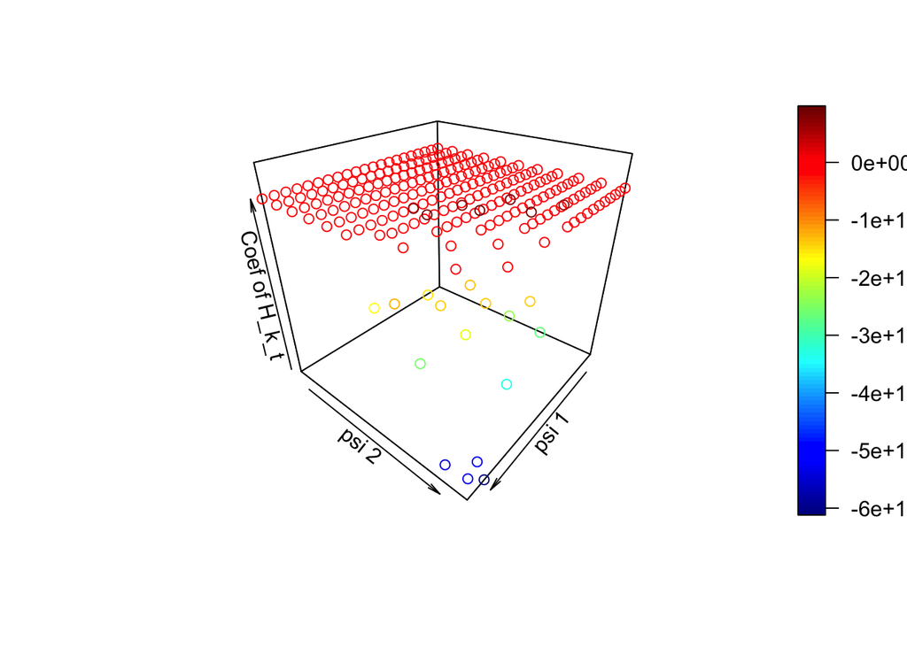

```r
psi_coef_data <- cbind(psi_grid_params_two_param, coef_hkt, coef_hkt_sum_policy)
colnames(psi_coef_data) <- c("psi_1", "psi_2", "coef_hkt", "coef_hkt_sum_policy")
scatter3D(x = psi_coef_data$psi_1, y= psi_coef_data$psi_2, z = psi_coef_data$coef_hkt,  theta = 130, phi = 30,
          xlab = "psi 1", ylab = "psi 2", zlab = "Coef of H_k_t")
```

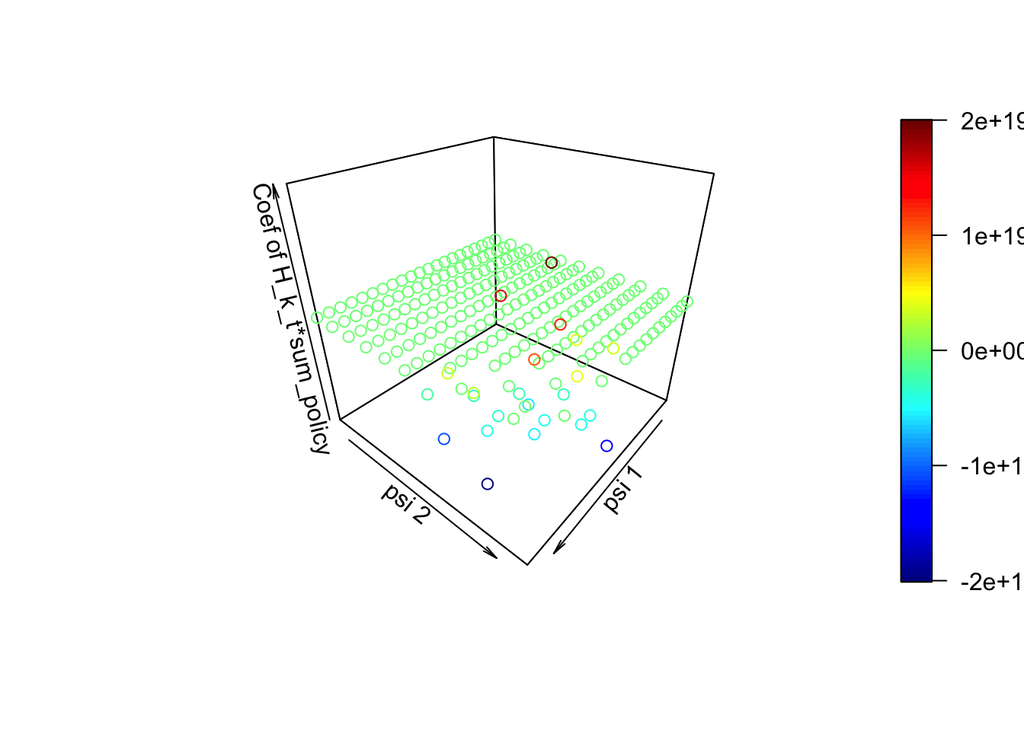

```r
scatter3D(x = psi_coef_data$psi_1, y= psi_coef_data$psi_2, z = psi_coef_data$coef_hkt_sum_policy,  theta = 130, phi = 30,
          xlab = "psi 1", ylab = "psi 2", zlab = "Coef of H_k_t*sum_policy")
```

```r
#make a table where rows indicate psi_1 and columns indicate psi_2 and values are the coefficient values of H_{s,k}(t)
coef_hkt_mat <- matrix(NA, nrow = length(unique(psi_grid_params_two_param$Var1)), ncol = length(unique(psi_grid_params_two_param$Var2)))
rownames(coef_hkt_mat) <- unique(psi_grid_params_two_param$Var1)
colnames(coef_hkt_mat) <- unique(psi_grid_params_two_param$Var2)
coef_hkt_mat[as.character(psi_coef_data$psi_1), as.character(psi_coef_data$psi_2)] <- psi_coef_data$coef_hkt
coef_hkt_mat
```

```
##                 -5            -4            -3            -2            -1
## -5   -6.094418e+04 -6.094418e+04 -6.094418e+04 -6.094418e+04 -6.094418e+04
## -4.5 -7.753425e+04 -7.753425e+04 -7.753425e+04 -7.753425e+04 -7.753425e+04
## -4   -9.827528e+04 -9.827528e+04 -9.827528e+04 -9.827528e+04 -9.827528e+04
## -3.5 -1.254816e+05 -1.254816e+05 -1.254816e+05 -1.254816e+05 -1.254816e+05
## -3   -1.628967e+05 -1.628967e+05 -1.628967e+05 -1.628967e+05 -1.628967e+05
## -2.5 -2.168469e+05 -2.168469e+05 -2.168469e+05 -2.168469e+05 -2.168469e+05
## -2   -2.984255e+05 -2.984255e+05 -2.984255e+05 -2.984255e+05 -2.984255e+05
## -1.5 -4.287203e+05 -4.287203e+05 -4.287203e+05 -4.287203e+05 -4.287203e+05
## -1   -6.492976e+05 -6.492976e+05 -6.492976e+05 -6.492976e+05 -6.492976e+05
## -0.5 -1.031212e+06 -1.031212e+06 -1.031212e+06 -1.031212e+06 -1.031212e+06
## 0    -1.679099e+06 -1.679099e+06 -1.679099e+06 -1.679099e+06 -1.679099e+06
## 0.5   6.386885e+18  6.386885e+18  6.386885e+18  6.386885e+18  6.386885e+18
## 1    -2.626216e+19 -2.626216e+19 -2.626216e+19 -2.626216e+19 -2.626216e+19
## 1.5  -7.534899e+06 -7.534899e+06 -7.534899e+06 -7.534899e+06 -7.534899e+06
## 2    -1.336349e+19 -1.336349e+19 -1.336349e+19 -1.336349e+19 -1.336349e+19
## 2.5   9.090211e+18  9.090211e+18  9.090211e+18  9.090211e+18  9.090211e+18
## 3    -3.321024e+19 -3.321024e+19 -3.321024e+19 -3.321024e+19 -3.321024e+19
## 3.5  -5.585907e+07 -5.585907e+07 -5.585907e+07 -5.585907e+07 -5.585907e+07
## 4    -6.119581e+19 -6.119581e+19 -6.119581e+19 -6.119581e+19 -6.119581e+19
## 4.5  -5.041374e+19 -5.041374e+19 -5.041374e+19 -5.041374e+19 -5.041374e+19
## 5    -5.294738e+19 -5.294738e+19 -5.294738e+19 -5.294738e+19 -5.294738e+19
##                  0             1             2             3             4
## -5   -6.094418e+04 -6.094418e+04 -6.094418e+04 -6.094418e+04 -6.094418e+04
## -4.5 -7.753425e+04 -7.753425e+04 -7.753425e+04 -7.753425e+04 -7.753425e+04
## -4   -9.827528e+04 -9.827528e+04 -9.827528e+04 -9.827528e+04 -9.827528e+04
## -3.5 -1.254816e+05 -1.254816e+05 -1.254816e+05 -1.254816e+05 -1.254816e+05
## -3   -1.628967e+05 -1.628967e+05 -1.628967e+05 -1.628967e+05 -1.628967e+05
## -2.5 -2.168469e+05 -2.168469e+05 -2.168469e+05 -2.168469e+05 -2.168469e+05
## -2   -2.984255e+05 -2.984255e+05 -2.984255e+05 -2.984255e+05 -2.984255e+05
## -1.5 -4.287203e+05 -4.287203e+05 -4.287203e+05 -4.287203e+05 -4.287203e+05
## -1   -6.492976e+05 -6.492976e+05 -6.492976e+05 -6.492976e+05 -6.492976e+05
## -0.5 -1.031212e+06 -1.031212e+06 -1.031212e+06 -1.031212e+06 -1.031212e+06
## 0    -1.679099e+06 -1.679099e+06 -1.679099e+06 -1.679099e+06 -1.679099e+06
## 0.5   6.386885e+18  6.386885e+18  6.386885e+18  6.386885e+18  6.386885e+18
## 1    -2.626216e+19 -2.626216e+19 -2.626216e+19 -2.626216e+19 -2.626216e+19
## 1.5  -7.534899e+06 -7.534899e+06 -7.534899e+06 -7.534899e+06 -7.534899e+06
## 2    -1.336349e+19 -1.336349e+19 -1.336349e+19 -1.336349e+19 -1.336349e+19
## 2.5   9.090211e+18  9.090211e+18  9.090211e+18  9.090211e+18  9.090211e+18
## 3    -3.321024e+19 -3.321024e+19 -3.321024e+19 -3.321024e+19 -3.321024e+19
```

[output cut: 11 more lines]

```
## -2   -2.984255e+05
## -1.5 -4.287203e+05
## -1   -6.492976e+05
## -0.5 -1.031212e+06
## 0    -1.679099e+06
## 0.5   6.386885e+18
## 1    -2.626216e+19
## 1.5  -7.534899e+06
## 2    -1.336349e+19
## 2.5   9.090211e+18
## 3    -3.321024e+19
## 3.5  -5.585907e+07
## 4    -6.119581e+19
## 4.5  -5.041374e+19
## 5    -5.294738e+19
```

```r
#make a table where rows indicate psi_1 and columns indicate psi_2 and values are the coefficient values of H_{s,k}(t)*sum_policy
coef_hkt_mat_sum_policy <- matrix(NA, nrow = length(unique(psi_grid_params_two_param$Var1)),
                                  ncol = length(unique(psi_grid_params_two_param$Var2)))
rownames(coef_hkt_mat_sum_policy) <- unique(psi_grid_params_two_param$Var1)
colnames(coef_hkt_mat_sum_policy) <- unique(psi_grid_params_two_param$Var2)
coef_hkt_mat_sum_policy[as.character(psi_coef_data$psi_1), as.character(psi_coef_data$psi_2)] <- psi_coef_data$coef_hkt_sum_policy
coef_hkt_mat_sum_policy
```

```
##                 -5            -4            -3            -2            -1
## -5    1.019997e+04  1.019997e+04  1.019997e+04  1.019997e+04  1.019997e+04
## -4.5  1.250985e+04  1.250985e+04  1.250985e+04  1.250985e+04  1.250985e+04
## -4    1.560116e+04  1.560116e+04  1.560116e+04  1.560116e+04  1.560116e+04
## -3.5  1.990495e+04  1.990495e+04  1.990495e+04  1.990495e+04  1.990495e+04
## -3    2.612702e+04  2.612702e+04  2.612702e+04  2.612702e+04  2.612702e+04
## -2.5  3.548561e+04  3.548561e+04  3.548561e+04  3.548561e+04  3.548561e+04
## -2    5.017200e+04  5.017200e+04  5.017200e+04  5.017200e+04  5.017200e+04
## -1.5  7.443719e+04  7.443719e+04  7.443719e+04  7.443719e+04  7.443719e+04
## -1    1.167066e+05  1.167066e+05  1.167066e+05  1.167066e+05  1.167066e+05
## -0.5  1.913418e+05  1.913418e+05  1.913418e+05  1.913418e+05  1.913418e+05
## 0     3.193298e+05  3.193298e+05  3.193298e+05  3.193298e+05  3.193298e+05
## 0.5  -1.401133e+19 -1.401133e+19 -1.401133e+19 -1.401133e+19 -1.401133e+19
## 1     3.770963e+18  3.770963e+18  3.770963e+18  3.770963e+18  3.770963e+18
## 1.5   1.486339e+06  1.486339e+06  1.486339e+06  1.486339e+06  1.486339e+06
## 2    -4.151783e+18 -4.151783e+18 -4.151783e+18 -4.151783e+18 -4.151783e+18
## 2.5  -4.203854e+18 -4.203854e+18 -4.203854e+18 -4.203854e+18 -4.203854e+18
## 3     4.294354e+18  4.294354e+18  4.294354e+18  4.294354e+18  4.294354e+18
## 3.5   1.115164e+07  1.115164e+07  1.115164e+07  1.115164e+07  1.115164e+07
## 4     1.286696e+19  1.286696e+19  1.286696e+19  1.286696e+19  1.286696e+19
## 4.5   2.001640e+19  2.001640e+19  2.001640e+19  2.001640e+19  2.001640e+19
## 5     1.099375e+19  1.099375e+19  1.099375e+19  1.099375e+19  1.099375e+19
##                  0             1             2             3             4
## -5    1.019997e+04  1.019997e+04  1.019997e+04  1.019997e+04  1.019997e+04
## -4.5  1.250985e+04  1.250985e+04  1.250985e+04  1.250985e+04  1.250985e+04
## -4    1.560116e+04  1.560116e+04  1.560116e+04  1.560116e+04  1.560116e+04
## -3.5  1.990495e+04  1.990495e+04  1.990495e+04  1.990495e+04  1.990495e+04
## -3    2.612702e+04  2.612702e+04  2.612702e+04  2.612702e+04  2.612702e+04
## -2.5  3.548561e+04  3.548561e+04  3.548561e+04  3.548561e+04  3.548561e+04
## -2    5.017200e+04  5.017200e+04  5.017200e+04  5.017200e+04  5.017200e+04
## -1.5  7.443719e+04  7.443719e+04  7.443719e+04  7.443719e+04  7.443719e+04
## -1    1.167066e+05  1.167066e+05  1.167066e+05  1.167066e+05  1.167066e+05
## -0.5  1.913418e+05  1.913418e+05  1.913418e+05  1.913418e+05  1.913418e+05
## 0     3.193298e+05  3.193298e+05  3.193298e+05  3.193298e+05  3.193298e+05
## 0.5  -1.401133e+19 -1.401133e+19 -1.401133e+19 -1.401133e+19 -1.401133e+19
## 1     3.770963e+18  3.770963e+18  3.770963e+18  3.770963e+18  3.770963e+18
## 1.5   1.486339e+06  1.486339e+06  1.486339e+06  1.486339e+06  1.486339e+06
## 2    -4.151783e+18 -4.151783e+18 -4.151783e+18 -4.151783e+18 -4.151783e+18
## 2.5  -4.203854e+18 -4.203854e+18 -4.203854e+18 -4.203854e+18 -4.203854e+18
## 3     4.294354e+18  4.294354e+18  4.294354e+18  4.294354e+18  4.294354e+18
```

[output cut: 11 more lines]

```
## -2    5.017200e+04
## -1.5  7.443719e+04
## -1    1.167066e+05
## -0.5  1.913418e+05
## 0     3.193298e+05
## 0.5  -1.401133e+19
## 1     3.770963e+18
## 1.5   1.486339e+06
## 2    -4.151783e+18
## 2.5  -4.203854e+18
## 3     4.294354e+18
## 3.5   1.115164e+07
## 4     1.286696e+19
## 4.5   2.001640e+19
## 5     1.099375e+19
```

```r
#the function to compute H(t) = H(t+1)/gamma_t, where gamma_t is given by parameters psi
compute_h_k_t <- function(h_k_t_plus_1, gamma_k_t ){
  h_k_t_plus_1/gamma_k_t
}



# # #the function to compute the mimicking potential outcomes (po)
# # #here: df = input dataset, gamma_t is the vector of gammas = exp(psi*(a_t - a_{t-1}))
# compute_mimick_po <- function(dataFrame, gamma_k_t){
#   #new_df is the dataset we will return, with the new rows appended
#   #we initialize it first as the input dataset df
#   new_data_frame <- data.frame()
#
#   #here, k is the time in which we observe the outcome and t is the time of the treatments
#   #so we have k > t
#   for(k in max(unique(dataFrame$Time_Period_ID)):2){
#     #we first pull out the risk of OD at time k, so Y_k
#     outcome_k <- dataFrame %>%
#       arrange(State) %>%
#       filter(Time_Period_ID == k) %>%
#       dplyr::pull(prop_dead)
#
#     #the first h(k+1) = Y(k+1)
#     hkt_plus_1_helper <- outcome_k
#     for(t in (k-1):1){
#       #for each t< k, taking outcome Y_k, and we blip down at each t: H(t) = H(t + 1)/gamma_t
#       hkt <- compute_h_k_t(hkt_plus_1_helper, gamma_k_t[dataFrame$Time_Period_ID == t])
#
#       #creating the dataset for time t -- we first only take the rows for time t
#       t_data_frame <- dataFrame %>%
#         arrange(State) %>%
#         filter(Time_Period_ID == t)
#       #then for those rows, we add the computed H(t) as a column
#       t_data_frame$hkt <- hkt
#
#       #also compute k - t
#       t_data_frame$len_tx <- k - t
#
#       #we then append the rows to the new_df
#       new_data_frame <- rbind(new_data_frame, t_data_frame)
#
#       #store the H(t) to be used to compute H(t-1), so we store it as the next ht_plus_1
#       hkt_plus_1_helper <- hkt
#     }
#   }
#   new_data_frame
# }

compute_mimick_potential_outcome <- function(dataFrame, gamma_k_t){
  #new_df is the dataset we will return, with the new rows appended
  #we initialize it first as the input dataset df
  new_data_frame <- data.frame()

  #here, k is the time in which we observe the outcome and t is the time of the treatments
  #so we have k > t
  for(k in max(unique(dataFrame$Time_Period_ID)):2){
    #we first pull out the risk of OD at time k, so Y_k
    outcome_k_data <- dataFrame %>%
      arrange(State) %>%
      filter(Time_Period_ID == k) %>%
      dplyr::select(State, prop_dead)

    #compute H_k(t) given gamma_k_t:
    #here, let t^* = treatment time
    #if t > t^*, then H_k(t) = Y_k since a_{t} - a_{t-1} = 0
    #if t <= t^*, then H_k(t) = Y_k/gamma_k_t
    outcome_k_data$hkt <- outcome_k_data$prop_dead/gamma_k_t

    # for(t in (k-1):1){
    #   #creating the dataset for time t -- we first only take the rows for time t
    #   t_data_frame <- dataFrame %>%
    #     arrange(State) %>%
    #     filter(Time_Period_ID == t)
    #
    #   #Compute H_k(t). Let t^* be the treatment time.
    #   #If t>t^*, then H_k(t) = Y_k. If t<= t^* then H_k(t) = Y_k/gamma_k_t
    #   t_data_frame$hkt <- ifelse(t_data_frame$Time_Period_Start <= t_data_frame$Intervention_First_Date, outcome_k, outcome_k/gamma_k_t)
    #
    #   #we then append the rows to the new_df
    #   new_data_frame <- rbind(new_data_frame, t_data_frame)
    #
    # }

    #filter the data for which A_{s,t} = 0 and the time interval that contains the treatment time since we only need these data
    #to predict treatment initiation for the model
    #we also filter so that the t < k
    untreated_and_first_tx_date_data <- dataFrame %>%
      arrange(State, Time_Period_ID) %>%
      filter(Time_Period_Start <= Intervention_First_Date,
             Time_Period_ID < k)

    #merge the filtered dataset with the outcome_k_data which contains the computed H_k(t)
    untreated_and_first_tx_date_data <- merge(untreated_and_first_tx_date_data, outcome_k_data[,c("State", "hkt")], by = "State")

    #compute k - t
    untreated_and_first_tx_date_data$k_minus_t <- k - untreated_and_first_tx_date_data$Time_Period_ID

    #we then append the rows to the new_data_frame
    new_data_frame <- rbind(new_data_frame, untreated_and_first_tx_date_data)
  }
  new_data_frame
}
```

## 4.3 $\gamma_t^k = exp(psi_1(a_t - a_{t-1}) + psi_2(a_t - a_{t-1})(k-t^*))$

Here, we take into account of the period of time the outcome was observed, after treatment. The longer the treatment period, the larger the effect. $\gamma_t^k = exp(\psi_1(a_t - a_{t-1}) + \psi_2(a_t - a_{t-1})(k-t))$

```r
#multiple parameter gamma
compute_mimick_po_w_gamma_function<- function(dataFrame, psi_grid_params, gamma_func){
  #new_df is the dataset we will return, with the new rows appended
  #we initialize it first as the input dataset dataFrame
  new_data_frame <- data.frame()

  #here, k is the time in which we observe the outcome and t is the time of the treatments
  #so we have k > t
  for(k in max(unique(dataFrame$Time_Period_ID)):2){
    #we first pull out the risk of OD at time k, so Y_k
    outcome_k <- dataFrame %>%
      arrange(State) %>%
      filter(Time_Period_ID == k) %>%
      dplyr::pull(prop_dead)

    #store h(k+1) = Y(k+1)
    hkt_plus_1 <- outcome_k
    for(t in (k-1):1){
      #compute gamma_t using function
      gamma_k_t <- gamma_func(dataFrame, k, t, psi_grid_params)

      #for each t< k, taking outcome Y_k, and we blip down at each t: H(t) = H(t + 1)/gamma_t
      hkt <- compute_h_k_t(hkt_plus_1, gamma_k_t)

      #creating the dataset for time t -- we first only take the rows for time t
      t_data_frame  <- dataFrame %>%
        arrange(State) %>%
        filter(Time_Period_ID == t)
      #then for those rows, we add the computed H(t) as a column
      t_data_frame$hkt <- hkt

      #also compute k - t
      t_data_frame$len_tx <- k - t

      #we then append the rows to the new_df
      new_df <- rbind(new_data_frame, t_data_frame )

      #store the H(t) to be used to compute H(t-1)
      hkt_plus_1 <- hkt
    }
  }
  new_data_frame
}
```

```r
#checked -5 to 5, coefficients became larger as grid went up, so try more negative
#checked -6 to -5
#checked -10 to -6
#checked -13 to -10
#checked -15 to -13
#create a vector of 100 psi
# psi_grid_params <- seq(-0.1012847, -0.1012846, length.out = 100)
psi_grid_params_two_param <- expand.grid(seq(-5, 5, length.out = 20), seq(-0.263, 0.263, by = 0.01))

#gamma function to compute the two parameter model
gamma_two_param <- function(df, k, t, psi_grid_params){
  #extract the treatment allocation
  df_subset_t <- df %>%
    arrange(State, Time_Period_ID) %>%
    filter(Time_Period_ID == t) %>%
    pull(Intervention_Redefined)

  if(t > 1){
    df_subset_t_minus_1 <- df %>%
      arrange(State, Time_Period_ID) %>%
      filter(Time_Period_ID == t-1) %>%
      pull(Intervention_Redefined)
  }else{
    df_subset <- df %>%
    arrange(State, Time_Period_ID) %>%
    filter(Time_Period_ID == t)

    df_subset_t_minus_1 <- rep(0, length(df_subset_t))
    df_subset_t_minus_1[df_subset$State == "Ohio"] <- df_subset$Intervention_Redefined[df_subset$State == "Ohio" &
                                                                                         df_subset$Time_Period_ID == t]
    df_subset_t_minus_1[df_subset$State == "Georgia"] <- df_subset$Intervention_Redefined[df_subset$State == "Georgia" &
                                                                                         df_subset$Time_Period_ID == t]
  }


  exp(unlist(psi_grid_params[1])*(df_subset_t - df_subset_t_minus_1) +
        unlist(psi_grid_params[2])*(df_subset_t - df_subset_t_minus_1)*(k-t))
}



#initialize the vector of coefficients for H(t) in treatment initiation model
coef_ht_1 <- coef_ht_2 <- rep(NA, nrow(psi_grid_params_two_param))
for(grid_point in 1:nrow(psi_grid_params_two_param)){
  #statement to print the status of the for loop
  if(grid_point%%10 == 0){print(grid_point)}

  #compute H(t) given the dataset and gamma_t
  data_w_ht <- compute_mimick_po_w_gamma_function(treat_data, psi_grid_params_two_param[grid_point,], gamma_two_param)

  #filter the dataset to only time periods when treatment hasn't occurred yet and the first time point in which treatment occurred
  model_data <- data_w_ht %>%
    filter(Time_Period_Start <= floor_date(Intervention_First_Date, "6 months"))

  #fit model for treatment initiation
  treat_model <- glm(Intervention_Redefined~
                       sum_policies +
                       ht +
                       Time_Period_ID +
                       ht*sum_policies,
                     data = model_data, family = "binomial")

  #store the coefficient for
  coef_ht_1[grid_point] <- coef(treat_model)["ht"]
  coef_ht_2[grid_point] <- coef(treat_model)["sum_policies:ht"]


}

coef_ht_1
coef_ht_2
psi_grid_params_two_param[200:201,]
```

[output not shown]